# Part 2: Exploration

## Integration: Harmony

CCA is the original integration method implemented in Seurat, and which we used above, but it can be slow for large datasets. In addition, it has a tendency to over-correct, meaning it might obscure biological variation in the data beyond simply correcting for the technical noise we actually want to get rid of.

In the case of this data, we are dealing with PBMCs from two donors, and as such we expect the same cell types in both samples. CCA is expected to perform well in this setting. If however we were dealing with samples which have very different cell type compositions, it might be a good idea to try different methods.

One alternative that has become quite popular in recent years is [Harmony](https://portals.broadinstitute.org/harmony/). It works very well for large datasets and produces good results. Though it can also suffer from overcorrection, it is generally less severe than CCA. Let’s try using it now.

```r
library(harmony)
scData <- RunHarmony(scData, group.by.vars = "orig.ident", reduction.use="pca")
```

```
Transposing data matrix
```

```
Initializing state using k-means centroids initialization
```

```
Harmony 1/10
```

```
Harmony 2/10
```

```
Harmony 3/10
```

```
Harmony 4/10
```

```
Harmony converged after 4 iterations
```

```r
scData <- FindNeighbors(scData, graph.name="harmonynn", reduction = "harmony")
```

```
Only one graph name supplied, storing nearest-neighbor graph only
```

```r
scData <- FindClusters(scData, graph.name="harmonynn", resolution = seq(0.2, 1.0, by=0.2))
```

```
Modularity Optimizer version 1.3.0 by Ludo Waltman and Nees Jan van Eck

Number of nodes: 11229
Number of edges: 101577

Running Louvain algorithm...
Maximum modularity in 10 random starts: 0.9508
Number of communities: 10
Elapsed time: 0 seconds
```

```
2 singletons identified. 8 final clusters.
```

```
Modularity Optimizer version 1.3.0 by Ludo Waltman and Nees Jan van Eck

Number of nodes: 11229
Number of edges: 101577

Running Louvain algorithm...
Maximum modularity in 10 random starts: 0.9216
Number of communities: 14
Elapsed time: 0 seconds
```

```
2 singletons identified. 12 final clusters.
```

```
Modularity Optimizer version 1.3.0 by Ludo Waltman and Nees Jan van Eck

Number of nodes: 11229
Number of edges: 101577

Running Louvain algorithm...
Maximum modularity in 10 random starts: 0.9001
Number of communities: 16
Elapsed time: 0 seconds
```

```
2 singletons identified. 14 final clusters.
```

```
Modularity Optimizer version 1.3.0 by Ludo Waltman and Nees Jan van Eck

Number of nodes: 11229
Number of edges: 101577

Running Louvain algorithm...
Maximum modularity in 10 random starts: 0.8840
Number of communities: 20
Elapsed time: 0 seconds
```

```
2 singletons identified. 18 final clusters.
```

```
Modularity Optimizer version 1.3.0 by Ludo Waltman and Nees Jan van Eck

Number of nodes: 11229
Number of edges: 101577

Running Louvain algorithm...
Maximum modularity in 10 random starts: 0.8690
Number of communities: 20
Elapsed time: 0 seconds
```

```
2 singletons identified. 18 final clusters.
```

```r
scData <- RunUMAP(scData, reduction = 'harmony', dims=1:30, reduction.name = 'umap.harmony')
```

**Trying out different integration methods**

In recent years, there has been increased emphasis on trying multiple different integration methods, rather than just one, as part of standard single cell analysis. This is because integration method results can vary wildly and choosing the results of only one blindly can bias the results. We can use [certain metrics](https://github.com/carmonalab/scIntegrationMetrics) to determine the level of batch mixing versus celltype mixing to determine which of the integration methods we try looks “the best”.

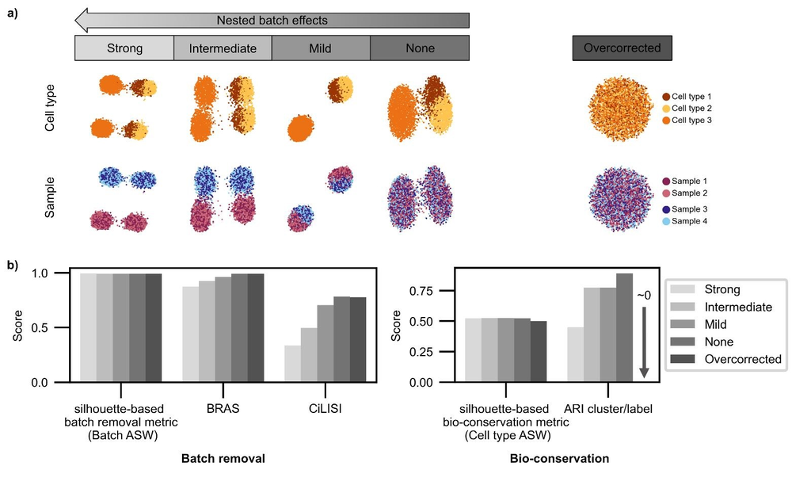

SC Integration Metrics

Take a look at the resulting object.

```r
scData
```

```
An object of class Seurat
27230 features across 11229 samples within 1 assay
Active assay: RNA (27230 features, 2000 variable features)
 3 layers present: data, counts, scale.data
 5 dimensional reductions calculated: pca, umap, integrated.cca, harmony, umap.harmony
```

You may notice 2 additional dimensional reductions, `harmony` as well as `umap.harmony` . The first is the harmony reduction which we got when we ran `RunHarmony`. The latter we got when we executed `RunUMAP` , providing the harmony reduction as input.

```r
colnames(scData@meta.data)
```

```
 [1] "orig.ident"        "nCount_RNA"        "nFeature_RNA"
 [4] "percent.mito"      "percent.ribo"      "percent.globin"
 [7] "RNA_snn_res.0.2"   "RNA_snn_res.0.4"   "RNA_snn_res.0.6"
[10] "RNA_snn_res.0.8"   "RNA_snn_res.1"     "seurat_clusters"
[13] "tcell_genes1"      "S.Score"           "G2M.Score"
[16] "Phase"             "SingleR_annot"     "TenX_annot"
[19] "harmonynn_res.0.2" "harmonynn_res.0.4" "harmonynn_res.0.6"
[22] "harmonynn_res.0.8" "harmonynn_res.1"
```

### Exercise

Let’s try repeating the steps from “Clustering” and “Cell Annotation” again, but this time using the Harmony integration.

```r
# your code here
# Hint: You can copy-and-paste the code starting from the "Clustree" section
# and simply change the `reduction` argument in the function call to DimPlot
# as well as the `prefix` argument to the clustree function call
```